# HWone

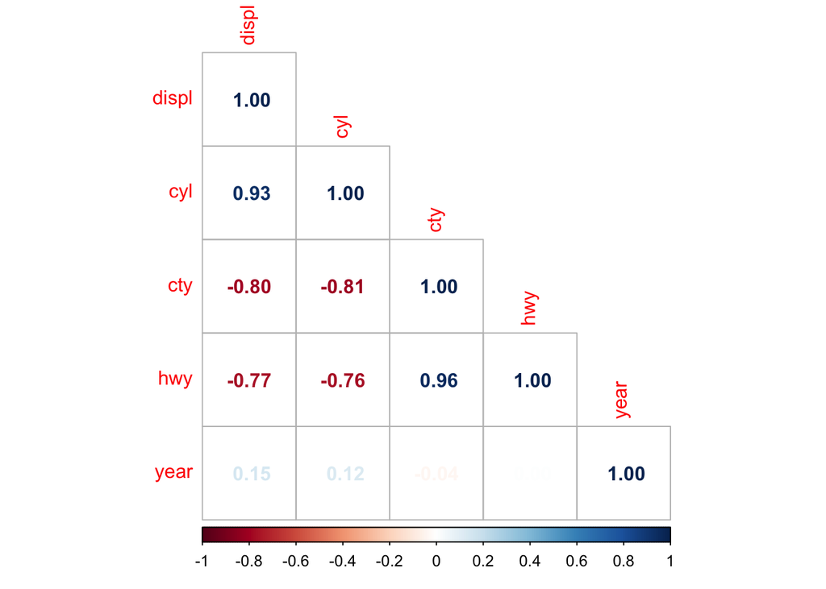

```r
corrplot(cor(newdata),method='number',type='lower')
```

There is a strong positive correlation between cylinders and engine displacement.This does not surprise me because of the research I did for exercise 4. Engine displacement has to do with how big and strong the engine is and it is based on how much volume the cylinders take up in the engine. This means that an engine with more cylinders will be stronger and bigger explaining the positive correlation here. There is a decently strong negative correlation between city mpg and engine displacement. This also does not surprise me because good city mpg requires less horsepower so the better city mpg a car has the smaller the engine should be(less cylinders less horsepower less gas burned) with less horsepower. There is also a decently strong negative correlation between city mpg and cylinders. Again based on the last observation this does not surprise me because if a car has good city mileage or good mileage in general the engine should have less cylinders increasing its mileage benefits. There is also a decently strong negative correlation between highway mpg and engine displacement and highway mpg and cylinders. These both also do not surprise me because if you have good highway mpg you would in theory have a smaller engine with less cylinders and less engine displacement. There is also a strong positive correlation between highway mpg and city mpg. This correlation makes sense because if a car has good mileage in the city it should have even better mileage on the highway because city mpg burns more gas than highway mpg. The last correlation on this graph is the year but none of the correlation numbers are strong enough to indicate any meaningful relationships which makes sense because the year is just when the car was made which shouldn’t really affect the engine construction.